# Support vector machine

## What is SVM?

SVM is a machine learning algorithm which comes under supervised learning. Which means first we need to train the machine, using the previous labeled data and based on the previously feeded data it predicts the possible class of some new test data.

## How SVM works?

As mentioned above SVM takes data to train the classifier and based on that data it draws planes which separates various classes, and then this algorithm selects the plane which separates the classes in the best possible manner. The selected plane is called Hyperplane. As this hyperplane devides the graph into various classes, new data can be classified according to the region that it falls in.

## How the Hyperplane is selected?

The plane with the maximum margin from both the classes is considered hyperplane, and to find the margin from both the classes SVM uses two support vectors.

# Example

Lets take an example where we have data of fluorine and chlorine quantity in the water, and if the water is good or bad to health.

So here we have two feature -> fluorine quantity and chlorine quantity classes -> bad and good

Now for new data of water, we need to create a model, which can classify whether the water is good or bad for health.

Following image represents that we have too many options to take hyperplane.

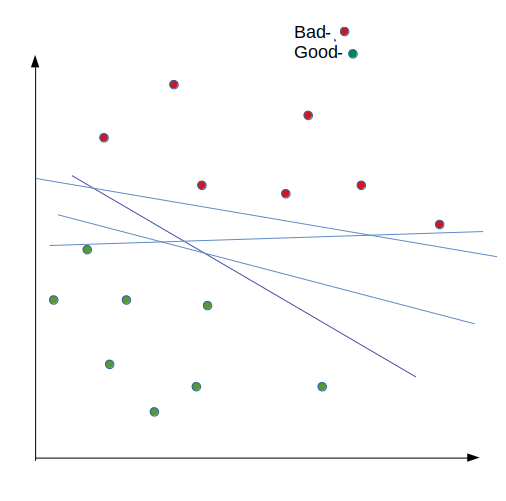

But we take the hyperplane which gives maximum margin from both the classes.

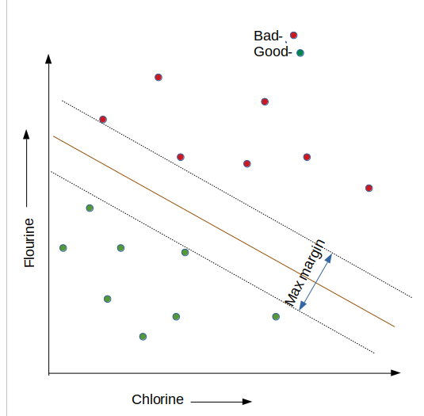

# Support Vector Machine algorithm python implementation

# ----------------------------------------------------------------------------------------

#### In the next cell we will import all required modules

#### 1- numpy is for numerical computation

#### 2- Matplotlib helps bhuild graphs

#### 3- Sklearn includes algorithm models

#### 4- make_blobs creates fake data

```python
import numpy as np
import matplotlib.pyplot as plt
from sklearn import svm
from sklearn.datasets.samples_generator import make_blobs
```

#### In this cell we are creating fake data using make_blobs

#### y = [0,1] or [bad, good]

#### n_samples = no of total samples we need

#### n_features = no of features(clorine , flourine)

#### centers = no of classes( good and bad)

```python
x, y = make_blobs(n_samples = 40, n_features = 2, centers  =2)
```

#### Now we need to create a classifier and fit it to the data

#### kernel represents that we want linear classification

```python
clf = svm.SVC(kernel = 'linear', C=1)
clf.fit(x, y)
```

```
SVC(C=1, cache_size=200, class_weight=None, coef0=0.0,
  decision_function_shape='ovr', degree=3, gamma='auto_deprecated',
  kernel='linear', max_iter=-1, probability=False, random_state=None,
  shrinking=True, tol=0.001, verbose=False)
```

#### Here we are plotting the data in two different colors according to their classes

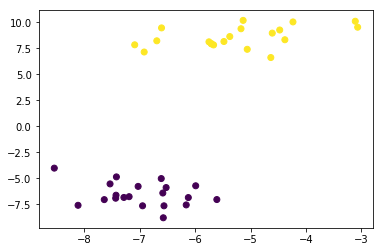

```python
plt.scatter(x[:, 0],x[:,1], c= y)
plt.show()
```

#### new_data is the data created by us to check what our models predicts for unknown data

#### to predict the class we use clf.predict()

```python
new_data = [[3,4]]
r= clf.predict(new_data)
if r ==0:
    result = "bad"
else:
    result = "good"
print("result of water test :", result)
```

```
result of water test : good
```